# Il ‘livello di forza’ dei personaggi in *Baki The Grappler*

Daniele Lizzio Bosco

01/02/2022

# Introduzione

*Baki The Grappler* è una serie di *manga* (fumetti giapponesi) e in seguito di animazione che racconta le avventure di un ragazzo - *Baki Hanma* - che fin da bambino si allena incessantemente nelle arti marziali per diventare un combattente sempre più forte, con l’obiettivo di riuscire ad affrontare e sconfiggere suo padre *Yujiro*, considerato “l’uomo più forte del pianeta”. Nel corso della storia Baki incontrerà una moltitudine di personaggi, alleati o rivali, che lo accompagneranno nel sogno di migliorare le sue capacità.

[figure not shown]

L’analisi svolta riguarda l’adattamento animato (che segue abbastanza fedelmente la storia originale). Esso è suddiviso in 5 stagioni, o parti, per un totale di 98 episodi. Nel corso delle stagioni compare un numero molto elevato di personaggi che si affrontano in tornei, sfide o battaglie individuali. Ogni combattimento presenta generalmente due sfidanti e termina con la vittoria di uno dei due (per esempio l’altro combattente è KO, o non è più in grado di lottare o decide di arrendersi). L’elevato numero di incontri permette quindi di poter definire una “classifica” di forza dei vari personaggi utilizzando la scienza delle reti.

In particolare, *Baki The Grappler* presenta:

- 98 episodi
- 106 personaggi che hanno combattuto almeno una volta
- 175 combattimenti

Questa analisi ci permetterà di:

- Determinare i personaggi principali della serie
- Valutare alcune proprietà generali della rete dei combattimenti tra i personaggi
- Valutare degli “score” che indicano la forza di un personaggio al variare del tempo
  - In particolare, useremo questi score per prevedere l’esito di possibili combattimenti futuri
  - In questo modo possiamo determinare lo score migliore
- Infine valuteremo l’andamento dello score migliore ristretto ai personaggi principali, permettendoci di stimare quando Baki sarà finalmente in grado di superare suo padre Yujiro.

### Il Dataset

Il dataset consiste di due file: il primo contenente la lista di tutti i combattimenti nel formato “Vincitore”, “Perdente” e episodio del combattimento, il secondo soltanto i combattimenti “incerti”, per esempio con più *manche* vinte prima da uno e poi dall’altro personaggio. Quest’ultimo file ci servirà come dataset ausiliario.

| Vincitore | Perdente | Episodio |
| --- | --- | --- |
| Baki | Naito | 1 |
| Baki | Kitazawa | 1 |
| Kuriyagawa | Kitazawa | 1 |
| Yuri Chakovsky | Sensarak Dinoy | 1 |
| Kaoru Hanayama | Tommy | 2 |
| Yuri Chakovsky | Baki | 2 |
| Yasha Ape | Ando | 3 |
| Yuri Chakovsky | Quevas | 3 |
| Baki | Yasha Ape | 4 |
| Kaoru Hanayama | Yuri Chakovsky | 5 |

## Personaggi di Baki

Le 5 parti di baki hanno un numero di episodi variabile. In particolare sono suddivise nel modo seguente:

- Prima parte: fino a ep. 24
- Seconda parte: da 25 a 48
- Terza parte: da 49 a 74
- Quarta parte: da 75 a 87
- Quinta parte: da 88 a 98

Osserviamo la distribuzione dei personaggi rispetto al primo episodio in cui combattono.

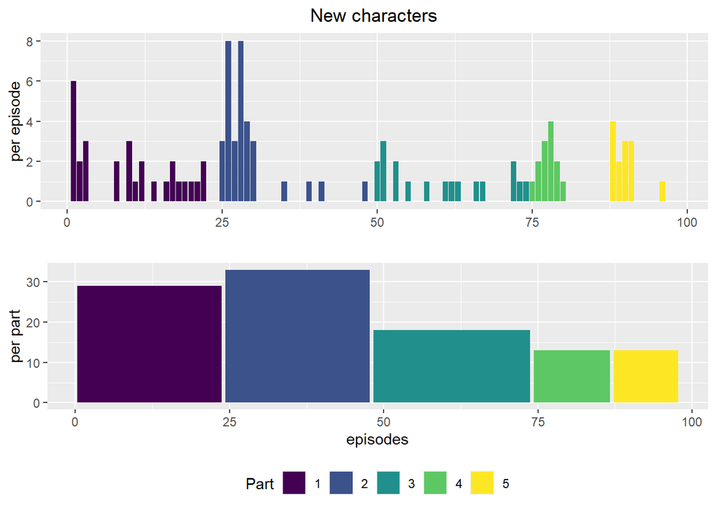

Ogni parte ha ambientazione e tema diversi, per cui (anche a causa della costante introduzione di nuovi personaggi) si può supporre che una buona parte dei personaggi siano “comparse”. Osserviamo infatti che la maggior parte dei personaggi è presenti in al più una sola parte:

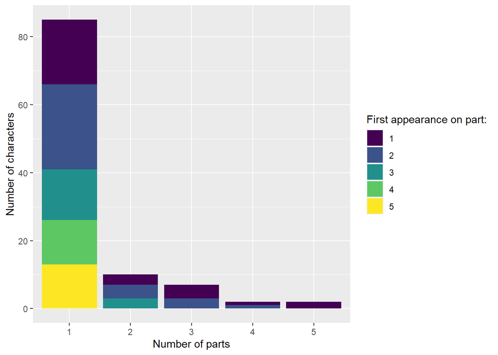

Di 106 personaggi più di 80 appaiono in una sola parte della serie, mentre solo 11 sono presenti in almeno 3 parti. Notiamo in particolare che Baki e suo padre Yujiro sono i soli personaggi presenti in ogni parte. D’ora in avanti, considereremo gli 11 personaggi presenti in almeno 3 parti come i personaggi principali di *Baki*.

| Personaggi principali | Primo episodio | Vittorie | Sconfitte |
| --- | --- | --- | --- |
| Baki | 1 | 33 | 5 |
| Kaoru Hanayama | 2 | 4 | 5 |
| Yujiro Hanma | 8 | 32 | 1 |
| Doppo Orochi | 17 | 6 | 4 |
| Kato | 17 | 2 | 3 |
| Shinogi Kosho | 18 | 1 | 3 |
| Motobe Izo | 21 | 1 | 3 |
| Retsu Kaio | 26 | 7 | 1 |
| Jack Hammer | 29 | 8 | 2 |
| Goki Shibukawa | 30 | 7 | 3 |
| Mr. Oliver | 48 | 9 | 4 |

## La rete dei combattimenti

Visualizziamo il grafo dei combattimenti e analizziamone qualche proprietà generale.

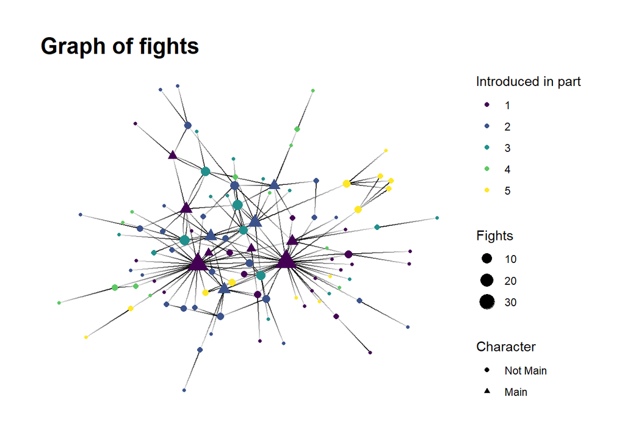

#### Distribuzione dei gradi

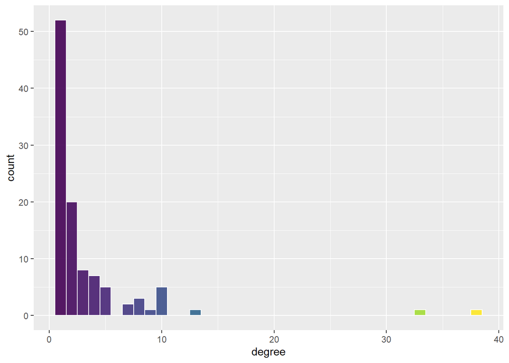

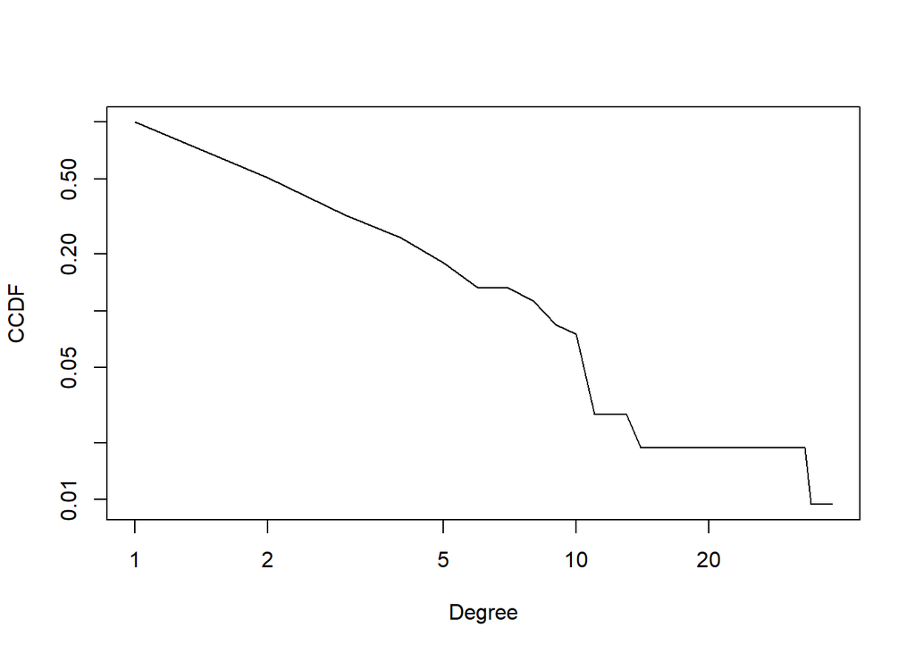

Osserviamo una distribuzione del tipo “scale free”, tipica di molte reti reali. Tra tutti, due nodi si contraddistinguono per il loro grado estremamente elevato, ovvero quelli corrispondenti a Baki e a Yujiro.

| Transitività | Distanza media | Diametro | Skewness |
| --- | --- | --- | --- |
| 0.0611354 | 3.173046 | 7 | 4.671303 |

Un dato molto interessante è l’indice di transitività discretamente basso.

- Uno dei motivi principali per cui accade ciò è che se due personaggi hanno lo stesso rivale, essi saranno più probabilmente alleati che nemici, e quindi non combatteranno tra loro.
- Inoltre molti combattimenti si svolgono all’interno di tornei a eliminazione diretta.

## Score

Possiamo adesso definire 4 indici di “forza” per ogni combattente:

- Win Rate
- Win-Loss Score
- Generalized Katz Score
- Page Rank

### Katz Score come indice di forza

- Proposto (con questo scopo) in ” *A network-based ranking system for US college football*” da Juyong Park e M. E. J. Newman
- È la differenza di due indici, il primo calcolato sulle vittorie, il secondo sulle sconfitte
- Intuitivamente, un nodo ha un punteggio vittorie (o sconfitte) elevato se vince (o perde) contro nodi con punteggio elevato o contro molti nodi
- È un indice più adatto rispetto alla differenza *out-degree - in-degree*, in quanto tiene conto anche delle vittorie (e sconfitte) “indirette”

### Page Rank

L’indice di Katz non tiene in conto il grado dei nodi. Intuitivamente, sconfiggere un combattente che ha perso contro molti avversari vale di meno rispetto a sconfiggere un avversario che ha perso meno volte. Nel caso di grafi regolari (come nei tornei di football americano) questo non è un problema, ma in reti con nodi di grado molto diverso l’indice Page Rank è più adatto, in quanto il contributo a ogni nodo è pesato in base al grado.

### Valutare lo score migliore

Vogliamo determinare se un dato *score* sia davvero indicativo della forza di un personaggio. Per fare ciò:

- Per ogni episodio costruiamo il grafo dei combattimenti avvenuti fino a quell’episodio
  - Il grafo sarà dato da una combinazione del grafo principale con il grafo ausiliare
- Per ogni grafo calcoliamo lo score di ogni personaggio
- Per ogni combattimento svolto nell’episodio successivo valutiamo se il vincitore è quello con lo score più alto
  - In tal caso diremo che l’esito è stato previsto correttamente
  - Escludiamo da questa analisi i combattimenti tra personaggi “nuovi”
    - Questo riduce il numero di combattimenti valutabili da 175 a 81
- La precisione dello score sarà il rapporto tra i combattimenti previsti correttamente e quelli valutabili.

## Risultati

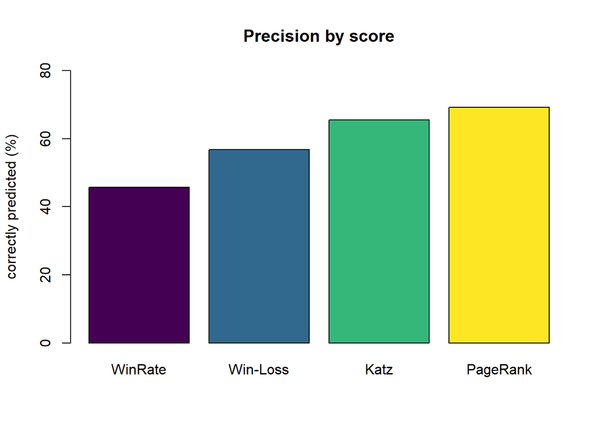

### Modifica nel calcolo della precisione

- Il criterio di valutazione scelto considera le previsioni tra personaggi con lo stesso score sbagliate a priori
- Per ovviare a questo problema, possiamo supporre che in caso di punteggio uguale l’algoritmo preveda il vincitore scegliendo “a caso”
  - Nella pratica, consideriamo 0.5 previsioni corrette in più per ogni combattimento tra personaggi con lo stesso score
- Questa modifica migliora sostanzialmente la precisione dei primi due score
- In ogni caso l’indice di Katz e Page Rank rimangono quelli con la precisione più elevata.

|  | Winrate | Win-Loss | Katz | PageRank |
| --- | --- | --- | --- | --- |
| Standard | 45.68 | 56.79 | 65.43 | 69.14 |
| Adjusted | 56.17 | 67.90 | 69.14 | 70.37 |

### Correlazione degli score

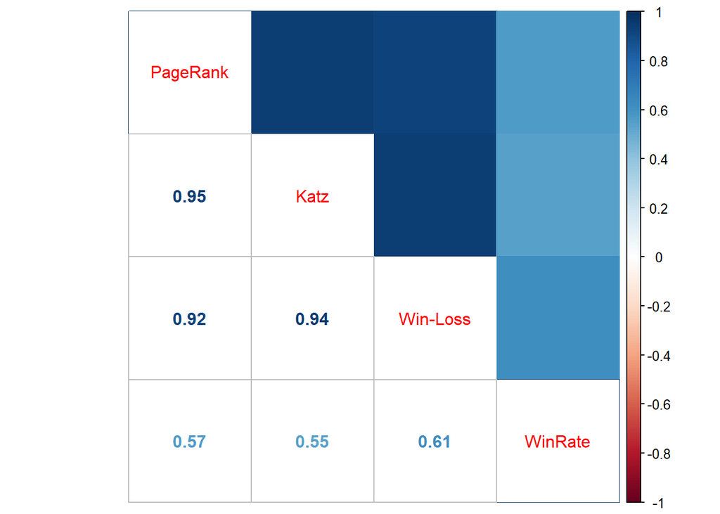

Notiamo che la correlazione degli score basati su PageRank, Katz e Win-Loss è estremamente elevata, come ci si poteva aspettare. Il WinRate è in ogni caso correlato positivamente con gli altri score.

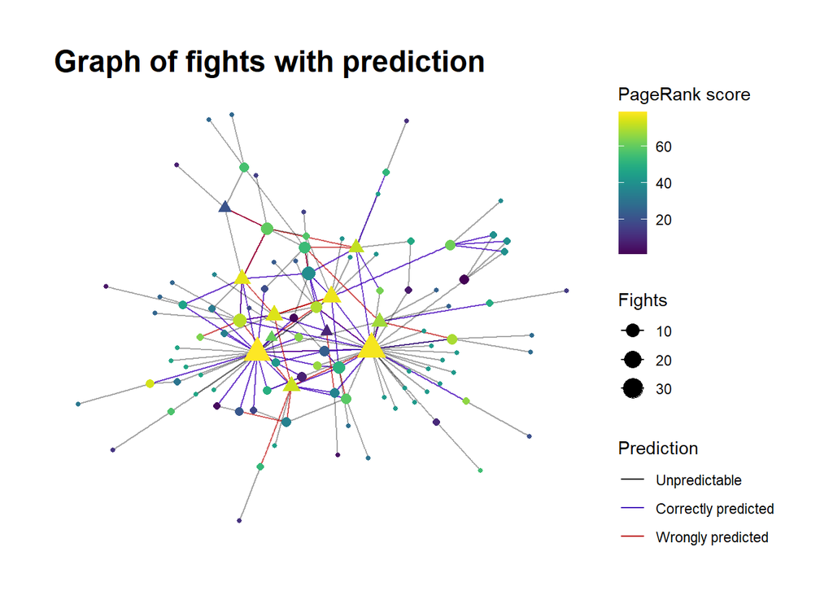

Abbiamo visto quindi che Page Rank fornisce un buono score per la forza dei personaggi. Visualizziamo adesso l’andamento di questo score relativo ai protagonisti episodio per episodio.

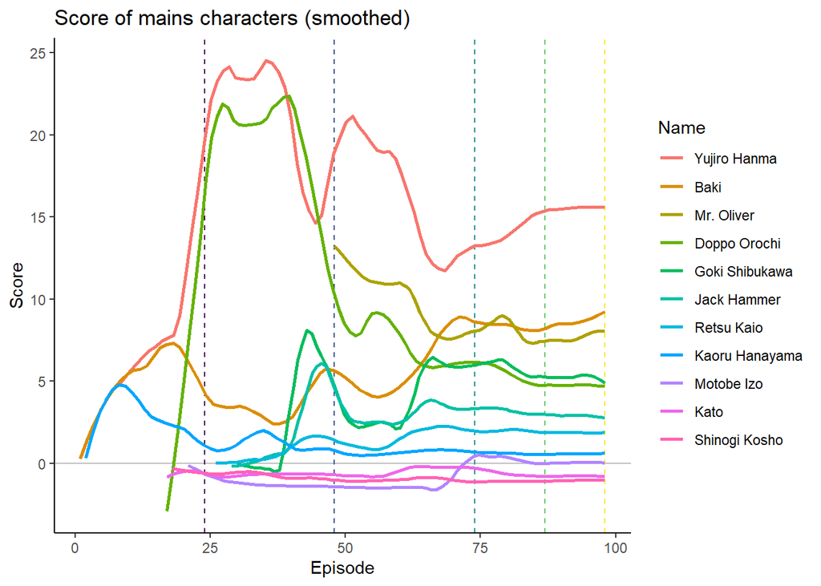

- Lo score in ogni episodio ha media nulla
- La maggior parte dei personaggi ha score negativo

|  | Last Score |
| --- | --- |
|  | Min. :-2.3195 |
|  | 1st Qu.:-0.6921 |
|  | Median :-0.5004 |
|  | Mean : 0.0000 |
|  | 3rd Qu.:-0.3752 |
|  | Max. :15.5383 |

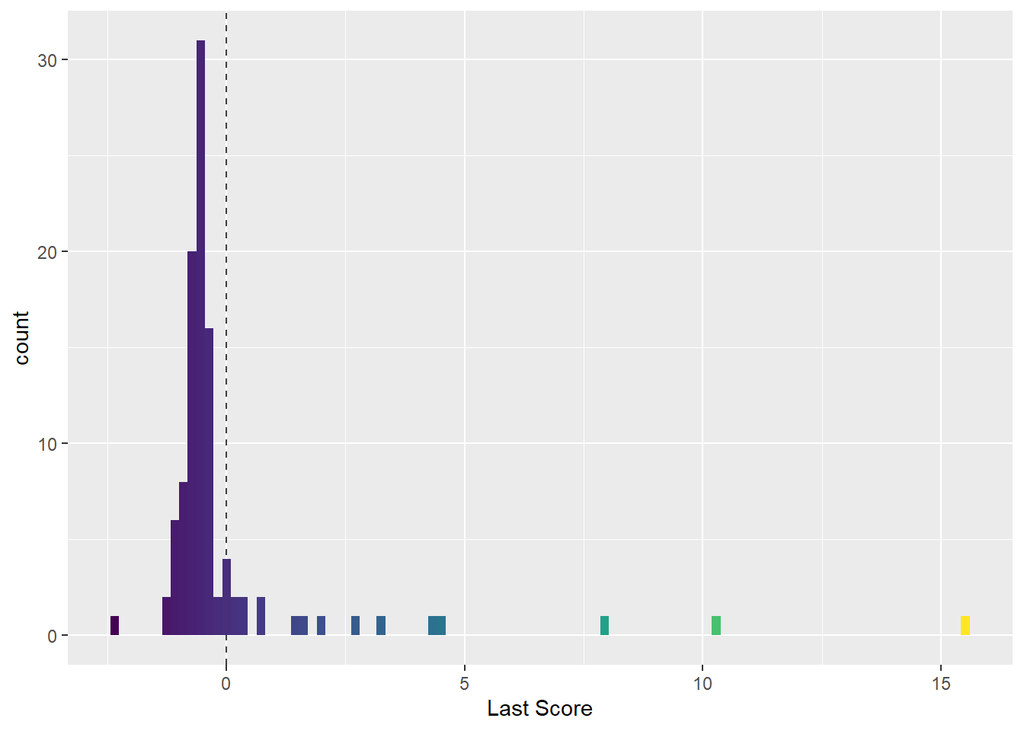

### Modello lineare

Notiamo che in generale lo score è abbastanza irregolare:

- Lo score può variare sensibilmente da episodio a episodio
- Ogni stagione è un arco narrativo a sé stante, quindi può essere interessante visualizzare gli score dei personaggi principali a ogni fine stagione
- Infatti molte stagioni di Baki terminano con uno scontro decisivo tra Baki e un altro personaggio “forte”, e determinano quindi il nuovo livello di forza dei personaggi.

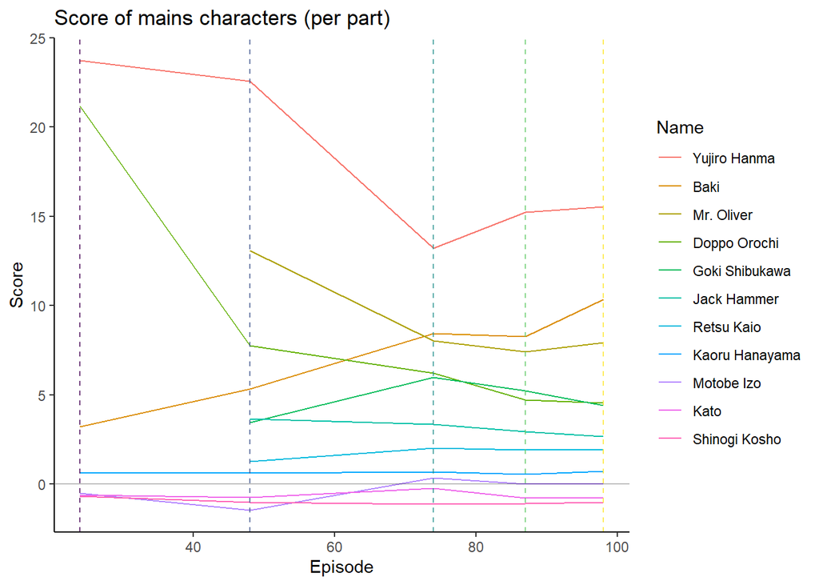

Possiamo ora fare qualche considerazione di carattere generale.

- Il livello di forza di Baki cresce quasi in ogni stagione
- Lo score degli altri personaggi tende generalmente a decrescere
- Una possibile spiegazione di questo fatto è che nella serie vengono introdotti personaggi sempre più forti
- Inoltre lo score calcolato è un indice di forza “relativo” e non “assoluto”

Supponendo che il livello di forza dei personaggi di Baki segua un andamento lineare, siamo in grado di supporre tra quanti episodi Baki riuscirà finalmente a superare suo padre.

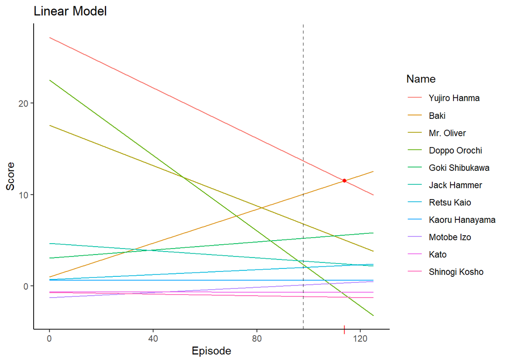

Otteniamo infine che, secondo questo modello, Baki potrebbe finalmente superare suo padre Yujiro intorno all’episodio 115. Non ci rimane quindi che aspettare le prossime stagioni di *Baki The Grappler* per vedere se la previsione è corretta o meno!